# R Notebook

`r`r library(Seurat) library(dplyr)

seurobj <- readRDS(‘output/10x-180831’)

# Quality control plots

The number of genes expressed descreases over time.

[figure not shown]

`r`r GenePlot(seurobj, ‘nUMI’, ‘nGene’, cex.use = 0.5)

`r`r PCElbowPlot(seurobj, num.pc=50) #TSNE+clustering run on 21 PC’s.

# PCA

Interesting to see: T4 and T5 contain a lot more variation than T1, T2 and T3, and PC2 seems to split T4 and T5. Could the split in PC2 describe the cells developing into white or brown?

```r
PCAPlot(seurobj, group.by='timepoint', pt.size=0.1)
```

[output not shown]

A few clusters in the data have much higher expression of ‘ADIPOQ’, ‘SCD’, ‘RBP4’, ‘G0S2’, ‘PLIN4’, ‘FABP5’. This seems to be captured by PC2.

`r`r FeaturePlot(seurobj, reduction.use=‘pca’, features.plot=c(‘PLA2G2A’, ‘MT1X’, ‘APOD’, ‘DPT’, ‘PTGDS’, ‘IGF2’), pt.size=1, cols.use=c(‘gray’, ‘blue’), no.legend=F, nCol=2)

PLA2G2A: http://www.jlr.org/content/early/2017/06/29/jlr.M076141 “…suggesting that PLA2G2A activates mitochondrial uncoupling in brown adipose tissue.”

PDGFRα/PDGFRβ signaling balance modulates progenitor cell differentiation into white and beige adipocytes. Based on PDGFRα or PDGFRβ deletion and ectopic expression experiments, we conclude that the PDGFRα/PDGFRβ signaling balance determines progenitor commitment to beige (PDGFRα) or white (PDGFRβ) adipogenesis. Our study suggests that adipocyte lineage specification and metabolism can be modulated through PDGFR signaling. http://dev.biologists.org/content/145/1/dev155861.long

`r`r FeaturePlot(seurobj, reduction.use=‘pca’, features.plot=c(‘PDGFRA’, ‘PDGFRB’), pt.size=1, cols.use=c(‘gray’, ‘blue’), no.legend=F, nCol=2)

# TSNE

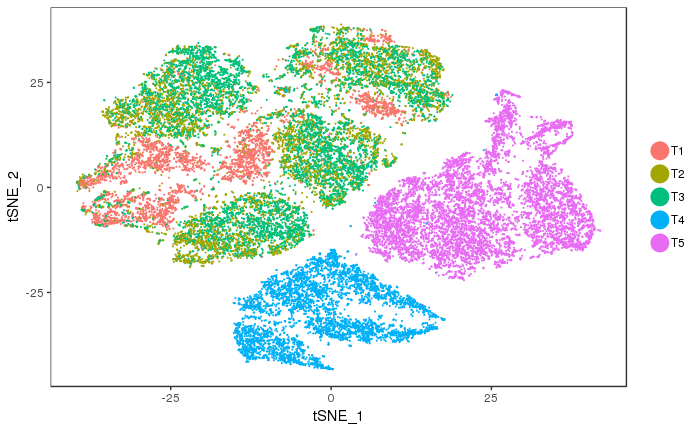

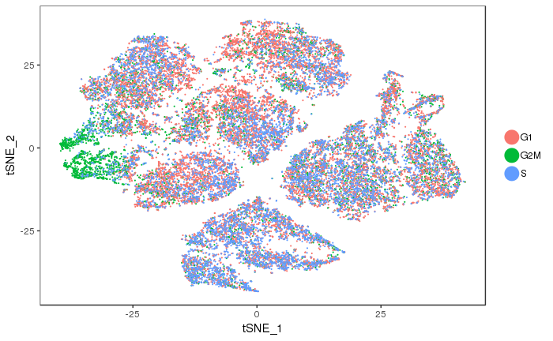

Cluster 11 = mixture cluster.

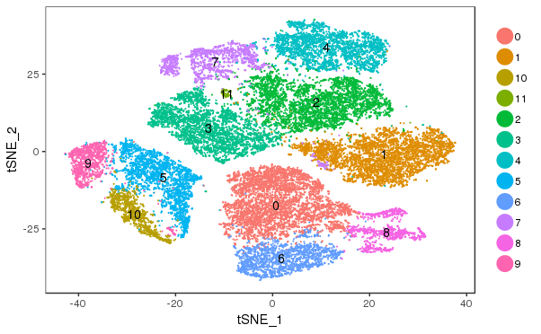

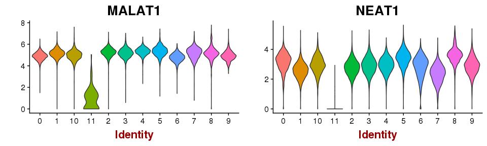

# Metadata feature plots

`r`r FeaturePlot(seurobj, reduction.use=‘tsne’, features.plot = ‘nUMI’, cols.use=c(‘grey’, ‘blue’), no.legend=F)

`r`r FeaturePlot(seurobj, features.plot = ‘percent.mito’, cols.use=c(‘grey’, ‘blue’), no.legend = F)

`r`r FeaturePlot(seurobj, reduction.use=‘tsne’, features.plot = ‘nGene’, cols.use=c(‘grey’, ‘blue’), no.legend = F)

# Markergene expression

`r`r FeaturePlot(seurobj, reduction.use=‘tsne’, features.plot = ‘EBF2’, cols.use=c(‘grey’, ‘blue’), no.legend = F)

`r`r FeaturePlot(seurobj, reduction.use=‘tsne’, features.plot = ‘TM4SF1’, cols.use=c(‘grey’, ‘blue’), no.legend = F)

`r`r FeaturePlot(seurobj, reduction.use=‘tsne’, features.plot = ‘LY6K’, cols.use=c(‘grey’, ‘blue’), no.legend = F)

`r`r FeaturePlot(seurobj, reduction.use=‘tsne’, features.plot = ‘PDGFRA’, cols.use=c(‘grey’, ‘blue’), no.legend = F)

# Markers literature

Marker genes for mature brown/beige compared to white mentioned by Seale 2016: UCP1, DIO2, CIDEA, PPARGC1A, PPARA, COX7A1, COX8B, PRDM16, EBF2. \

`r`r VlnPlot(seurobj, features.plot=c(‘UCP1’, ‘DIO2’, ‘CIDEA’, ‘PPARGC1A’, ‘PPARA’, ‘COX7A1’, ‘PRDM16’, ‘EBF2’), group.by=‘timepoint’, point.size.use = -1, nCol=2)

Based on PDGFRα or PDGFRβ deletion and ectopic expression experiments, we conclude that the PDGFRα/PDGFRβ signaling balance determines progenitor commitment to beige (PDGFRα) or white (PDGFRβ) adipogenesis. Our study suggests that adipocyte lineage specification and metabolism can be modulated through PDGFR signaling. http://dev.biologists.org/content/145/1/dev155861.long

`r`r FeaturePlot(seurobj, reduction.use=‘pca’, features.plot=c(‘PDGFRA’, ‘PDGFRB’), pt.size=1, cols.use=c(‘gray’, ‘blue’), no.legend=F, nCol=2)

`r`r FeaturePlot(seurobj, reduction.use=‘tsne’, features.plot=c(‘PDGFRA’, ‘PDGFRB’), pt.size=1, cols.use=c(‘gray’, ‘blue’), no.legend=F, nCol=2)

`r`r GenePlot(SetAllIdent(seurobj, id=‘timepoint’), gene1=‘PDGFRA’, gene2=‘PDGFRB’, cex.use=0.5)

# Figures for report

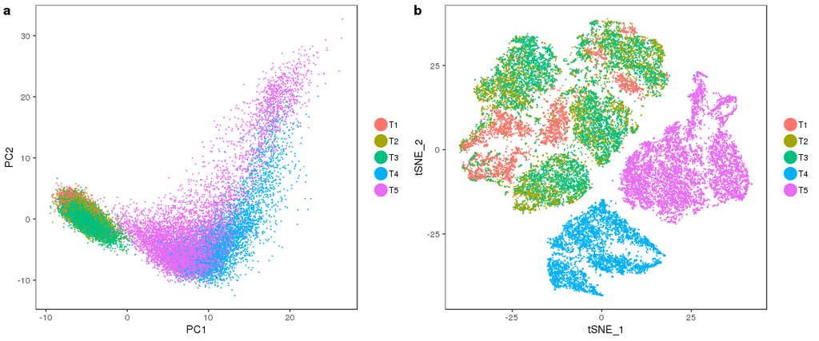

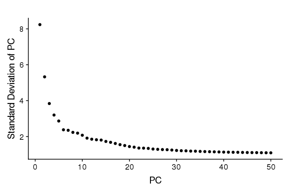

```r
sfig1 <- PCElbowPlot(seurobj, num.pc=50) #TSNE+clustering run on 21 PC's.
save_plot("../plots/supplementary_figures/sfig_180831_pcelbow.pdf", sfig1, base_width=6, base_height=4)
sfig1
```

[figure not shown]

```r
#sfig: tsne cell cycle
#sfig: numi, pm, ngene
sfig2 <- TSNEPlot(seurobj, group.by='Phase', pt.size=0.1)
```

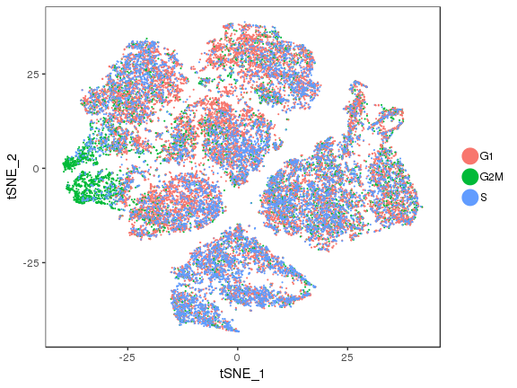

```r
save_plot("../plots/supplementary_figures/sfig_180831_tsne_cellcycle.pdf", sfig2, base_width=6, base_height=4.5)
sfig2
```

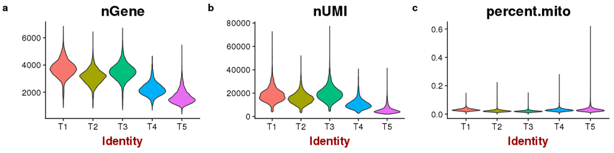